# NBA Wage Prediction by Using Machine Learning

[figure not shown]

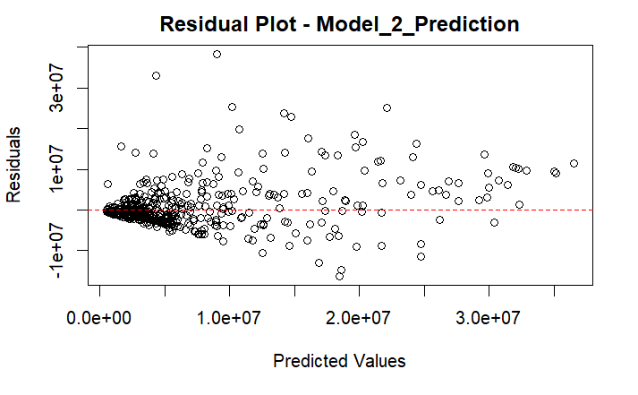

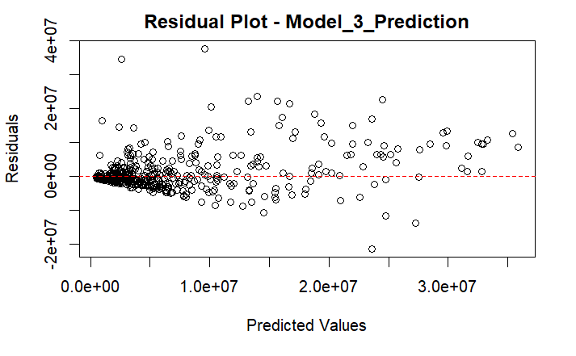

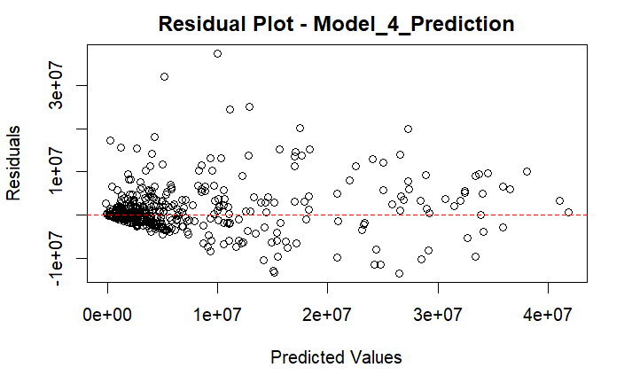

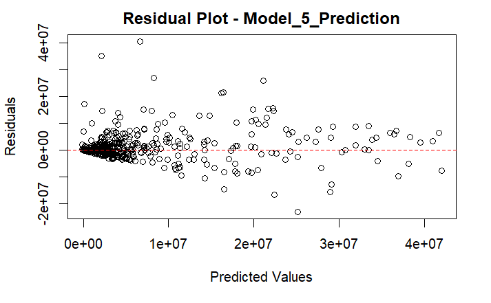

[figure not shown]

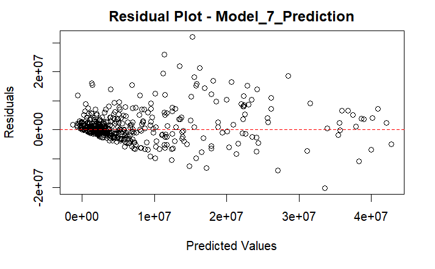

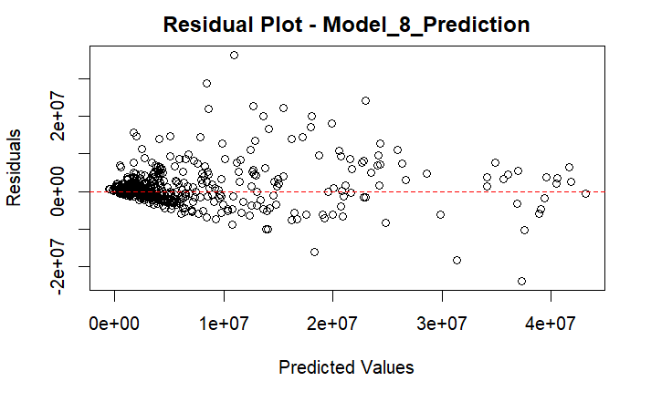

[figure not shown]

```r
# Function to create residual plot for a model
create_residual_plot <- function(model_name, prediction_column) {
  # Calculate the residuals
  residuals <- result_df$Actual_Wage - result_df[[prediction_column]]

  # Plot the residuals against the predicted values
  plot(result_df[[prediction_column]], residuals,
       xlab = "Predicted Values", ylab = "Residuals",
       main = paste("Residual Plot -", model_name))

  # Add a horizontal line at y = 0
  abline(h = 0, col = "red", lty = 2)
}

# Iterate over the models in result_df and create residual plots
for (i in 3:ncol(result_df)) {
  model_name <- colnames(result_df)[i]
  prediction_column <- colnames(result_df)[i]
  create_residual_plot(model_name, prediction_column)
}
```

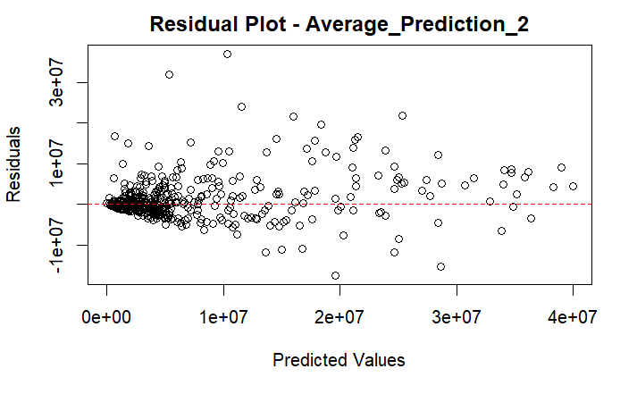

```r
NA
```

The provided code includes several analyses and visualizations to evaluate the performance of different models and their predictions in terms of Mean Squared Error (MSE), R-squared values, learning curves, and residual plots. Here is a summary of the key findings:

1. Performance Comparison: The code calculates the MSE values for each model and the average predictions. It then creates a bar plot to compare the performance of the models based on MSE. Additionally, the R-squared values are calculated and plotted in a separate bar plot for comparison.
2. Scatter Plots: The code generates scatter plots for each model, showing the relationship between the actual wages and predicted values. A reference line is included to indicate perfect predictions.
3. Best Predictions: A scatter plot is created specifically for the best predictions, showing the relationship between actual wages and the best-predicted values.
4. Learning Curves: The code generates learning curves for each model, showing how the MSE changes as the training sample size increases. This helps assess the model’s performance as more data is used for training.
5. Residual Plots: Residual plots are created for each model to visualize the distribution of residuals (the differences between actual wages and predicted values) against the predicted values. A horizontal line at y = 0 helps identify patterns or biases in the predictions.

## Conclusion

```r
# Extract the performance metrics for all models and average predictions
model_names <- c("Model 1", "Model 2", "Model 3", "Model 4", "Model 5", "Model 6", "Model 7", "Model 8", "Average", "Average 2")
mse_values <- c(mean((result_df$Model_1_Prediction - result_df$Actual_Wage)^2),
                mean((result_df$Model_2_Prediction - result_df$Actual_Wage)^2),
                mean((result_df$Model_3_Prediction - result_df$Actual_Wage)^2),
                mean((result_df$Model_4_Prediction - result_df$Actual_Wage)^2),
                mean((result_df$Model_5_Prediction - result_df$Actual_Wage)^2),
                mean((result_df$Model_6_Prediction - result_df$Actual_Wage)^2),
                mean((result_df$Model_7_Prediction - result_df$Actual_Wage)^2),
                mean((result_df$Model_8_Prediction - result_df$Actual_Wage)^2),
                mean((result_df$Average_Prediction - result_df$Actual_Wage)^2),
                mean((result_df$Average_Prediction_2 - result_df$Actual_Wage)^2))

# Calculate the R-squared values
r_squared_values <- c(summary(lm(Actual_Wage ~ Model_1_Prediction, data = result_df))$r.squared,
                      summary(lm(Actual_Wage ~ Model_2_Prediction, data = result_df))$r.squared,
                      summary(lm(Actual_Wage ~ Model_3_Prediction, data = result_df))$r.squared,
                      summary(lm(Actual_Wage ~ Model_4_Prediction, data = result_df))$r.squared,
                      summary(lm(Actual_Wage ~ Model_5_Prediction, data = result_df))$r.squared,
                      summary(lm(Actual_Wage ~ Model_6_Prediction, data = result_df))$r.squared,
                      summary(lm(Actual_Wage ~ Model_7_Prediction, data = result_df))$r.squared,
                      summary(lm(Actual_Wage ~ Model_8_Prediction, data = result_df))$r.squared,
                      summary(lm(Actual_Wage ~ Average_Prediction, data = result_df))$r.squared,
                      summary(lm(Actual_Wage ~ Average_Prediction_2, data = result_df))$r.squared)

# Create a data frame for the performance metrics
performance_df <- data.frame(Model = model_names, MSE = mse_values, R_squared = r_squared_values)

# Print the performance metrics table
print(performance_df)
```

| Model | MSE | R_squared |
| --- | --- | --- |
| Model 1 | 3.644848e+13 | 0.7292750 |
| Model 2 | 3.633560e+13 | 0.7279088 |
| Model 3 | 3.639934e+13 | 0.7302590 |
| Model 4 | 3.273062e+13 | 0.7406759 |
| Model 5 | 3.436903e+13 | 0.7258124 |
| Model 6 | 3.417681e+13 | 0.7229784 |
| Model 7 | 3.243777e+13 | 0.7405071 |
| Model 8 | 3.426900e+13 | 0.7245721 |
| Average | 3.173610e+13 | 0.7568047 |
| Average 2 | 3.092944e+13 | 0.7625056 |

```r
NA
```

1. Model 1:
   - MSE: 3.644848e+13
   - R-squared: 0.7292750
2. Model 2:
   - MSE: 3.633560e+13
   - R-squared: 0.7279088
3. Model 3:
   - MSE: 3.639934e+13
   - R-squared: 0.7302590
4. Model 4:
   - MSE: 3.273062e+13
   - R-squared: 0.7406759
5. Model 5:
   - MSE: 3.436903e+13
   - R-squared: 0.7258124
6. Model 6:
   - MSE: 3.417681e+13
   - R-squared: 0.7229784
7. Model 7:
   - MSE: 3.243777e+13
   - R-squared: 0.7405071
8. Model 8:
   - MSE: 3.426900e+13
   - R-squared: 0.7245721

Average Metrics:

- Average MSE: 3.173610e+13
- Average R-squared: 0.7568047

Average Metrics 2:

- Average MSE: 3.092944e+13
- Average R-squared: 0.7625056

Further analysis is required to understand the underlying factors contributing to the differences in performance between models. Evaluating additional metrics, conducting statistical significance tests, and considering the interpretability of the models can provide a more comprehensive analysis. Additionally, investigating the impact of specific features on the model’s performance could help identify areas for improvement and potentially enhance the accuracy of the wage predictions.